#### Note: This notebook contains only the dimensionality reduction, clustering and customer segment identification steps of the project. Code and discussion for data preprocessing and exploration can be found in Identify_Customer_Segments_Preprocessing.ipynb.

# Project: Identify Customer Segments

In this project, you will apply unsupervised learning techniques to identify segments of the population that form the core customer base for a mail-order sales company in Germany. These segments can then be used to direct marketing campaigns towards audiences that will have the highest expected rate of returns. The data that you will use has been provided by our partners at Bertelsmann Arvato Analytics, and represents a real-life data science task.

This notebook will help you complete this task by providing a framework within which you will perform your analysis steps. In each step of the project, you will see some text describing the subtask that you will perform, followed by one or more code cells for you to complete your work. **Feel free to add additional code and markdown cells as you go along so that you can explore everything in precise chunks.** The code cells provided in the base template will outline only the major tasks, and will usually not be enough to cover all of the minor tasks that comprise it.

It should be noted that while there will be precise guidelines on how you should handle certain tasks in the project, there will also be places where an exact specification is not provided. **There will be times in the project where you will need to make and justify your own decisions on how to treat the data.** These are places where there may not be only one way to handle the data. In real-life tasks, there may be many valid ways to approach an analysis task. One of the most important things you can do is clearly document your approach so that other scientists can understand the decisions you've made.

At the end of most sections, there will be a Markdown cell labeled **Discussion**. In these cells, you will report your findings for the completed section, as well as document the decisions that you made in your approach to each subtask. **Your project will be evaluated not just on the code used to complete the tasks outlined, but also your communication about your observations and conclusions at each stage.**

```python
# import libraries here; add more as necessary
import numpy as np
import pandas as pd
import matplotlib.pyplot as plt
import seaborn as sns
from sklearn.preprocessing import Imputer
from sklearn.preprocessing import StandardScaler
from sklearn.decomposition import PCA
from sklearn.cluster import KMeans
from sklearn.metrics import silhouette_score, calinski_harabaz_score
import Utils

# magic word for producing visualizations in notebook
%matplotlib inline
```

### Step 0: Load the Data

There are four files associated with this project (not including this one):

- `Udacity_AZDIAS_Subset.csv`: Demographics data for the general population of Germany; 891211 persons (rows) x 85 features (columns).
- `Udacity_CUSTOMERS_Subset.csv`: Demographics data for customers of a mail-order company; 191652 persons (rows) x 85 features (columns).
- `Data_Dictionary.md`: Detailed information file about the features in the provided datasets.
- `AZDIAS_Feature_Summary.csv`: Summary of feature attributes for demographics data; 85 features (rows) x 4 columns

```python
# Load in the general demographics data.
azdias = pd.read_csv('Udacity_AZDIAS_Subset.csv', delimiter=';')

# Load in the feature summary file.
feat_info = pd.read_csv('AZDIAS_Feature_Summary.csv', delimiter=';')
```

```python
# Load clean data using pipeline developed in Identify_Customer_Segments_Preprocessing.ipynb
data = Utils.clean_data(azdias, feat_info)
```

## Step 2: Feature Transformation

### Step 2.1: Apply Feature Scaling

Standardize variables as z-scores.

```python
# Note that sklearn.impute.IterativeImputer is not yet available in the stable version of sklearn
# I will update this notebook when it is available
# imputer = IterativeImputer(estimator=GradientBoostingRegressor(n_estimators=20), max_iter=20, imputation_order='random', verbose=1, random_state=874413)
# In the meantime, mean imputer has been implemented in the clean_data() function
```

```python
# Apply feature scaling to the general population demographics data.
idx, lab = data.index, data.columns
imputer = Imputer().fit(data)
data = imputer.transform(data)
scaler = StandardScaler()
data = scaler.fit_transform(data)
data = pd.DataFrame(data, index=idx, columns=lab)
```

### Discussion 2.1: Apply Feature Scaling

I scaled features using StandardScaler, as suggested, which transforms variables into z-scores. The transformed variables have zero mean and unit variance. Scaling is necessary for principal components analysis.

Principal components analysis (PCA) produces the best rank-k approximation of the original variance matrix (the variance matrix of our dataframe in its scaled feature space). Using a singular value decomposition, PCA minimzes the squared norm of the difference between that pre-PCA variance matrix and the variance matrix of the principal components (i.e. the left singular vectors scaled by their corresponding singular values). In other words, PCA minimizes the difference in total variance.

When features are in different scales, the features in larger scales are likely to have greater variance and the PCA process will therefore weight them higher when minimizing the difference total variance. Variance scales quadratically with unit size (i.e. Var(c*X) = c*c*Var(X) where c is a constant)*. In our case, without scaling the data the first principal component appears to explain more than 99% of the variance--a nonsensical result that I accidently produced with a coding error. But feature scales are arbitrary--how we measure information is always chosen by humans--so we are justified in transforming variables into units that better capture the relationships we wish to estimate. Standardizing our features puts them in the same space, giving them equal weight in the PCA process.

I want to briefly discuss missing data. I used mean imputation because sklearn hasn't yet implemented multiple imputation. Approaches like mean imputation can often increase bias. such methods are generally inappropriate for PCA because they artificially shrink the variances of features with imputed values. Still, mean imputation may less biased than listwise deletion in many cases. Sklearn is adapting to the needs of its users and will soon implement its sklearn.impute.IterativeImputer module, which is currently available in the developer version of sklearn. I intend to update this notebook when that module is available.

### Step 2.2: Perform Dimensionality Reduction

On your scaled data, you are now ready to apply dimensionality reduction techniques.

```python
# Apply PCA to the data.
pca = PCA(random_state=325490)
data_pca = pca.fit_transform(data)
data_pca = pd.DataFrame(data_pca)
```

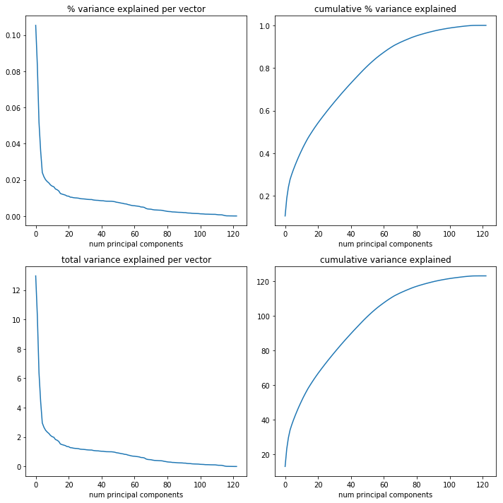

```python
# Investigate the variance accounted for by each principal component.

plt.rcParams["figure.figsize"] = (10, 10)
fig = plt.Figure()

# percent of total variance for each vector
plt.subplot(2, 2, 1)
plt.plot(pca.explained_variance_ratio_)
plt.title('% variance explained per vector')
plt.xlabel('num principal components')

# cumulative sum of percent of variance
cumulative_percent_variance = pca.explained_variance_ratio_.cumsum()
plt.subplot(2, 2, 2)
plt.plot(cumulative_percent_variance)
plt.title('cumulative % variance explained')
plt.xlabel('num principal components')

# total variance explained by each vector
plt.subplot(2, 2, 3)
plt.plot(pca.explained_variance_)
plt.title('total variance explained per vector')
plt.xlabel('num principal components')

# cumulative sum of variance
cumulative_variance = pca.explained_variance_.cumsum()
plt.subplot(2, 2, 4)
plt.plot(cumulative_variance)
plt.title('cumulative variance explained')
plt.xlabel('num principal components')

plt.tight_layout()
plt.show()
```

```python
print('% of variance explained by first 5 PC: ', pca.explained_variance_ratio_[0:5])
print('cumulative % variance explained by first 5 PC: ', cumulative_percent_variance[0:5])
print()
print('total variance explained by first 5 PC: ', pca.explained_variance_[0:5])
print('cumulative variance explained by first 5 PC: ', cumulative_variance[0:5])
```

```
% of variance explained by first 5 PC:  [0.10537913 0.08319596 0.05175434 0.03594616 0.02405539]
cumulative % variance explained by first 5 PC:  [0.10537913 0.18857508 0.24032943 0.27627559 0.30033098]

total variance explained by first 5 PC:  [12.9616491  10.23311536  6.36579194  4.42138374  2.95881655]
cumulative variance explained by first 5 PC:  [12.9616491  23.19476445 29.5605564  33.98194014 36.94075669]
```

```python
print(pca.explained_variance_ratio_[0:10])
print()
print(cumulative_percent_variance[0:10])
print()
print([np.power((1-np.power(0.5, 1/data_pca.shape[0])), 1/components) for components in range(1,15)])
```

```
[0.10537913 0.08319596 0.05175434 0.03594616 0.02405539 0.02166723
 0.02003489 0.01903521 0.01825149 0.01714887]

[0.10537913 0.18857508 0.24032943 0.27627559 0.30033098 0.32199821
 0.3420331  0.36106831 0.3793198  0.39646867]

[8.686475648778114e-07, 0.0009320126420160895, 0.009541453442620215, 0.03052888209574811, 0.061343524004833776, 0.09768036364909896, 0.1361822531077849, 0.17472516159886106, 0.21209878393407583, 0.24767624836635785, 0.2811808778116568, 0.3125385794571591, 0.3417883066950458, 0.3690287971253529]
```

```python
# Re-apply PCA to the data while selecting for number of components to retain.
# Apply PCA to the data.
var_idx = 0
var = 0
for i in range(0, len(cumulative_percent_variance)):
    if cumulative_percent_variance[i] > 0.3:
        var_idx = i
        var = cumulative_percent_variance[i]
        break

pca = PCA(n_components=var_idx+1, random_state=325490)
data_pca = pca.fit_transform(data)
data_pca = pd.DataFrame(data_pca)
print(f'Keeping {var_idx+1} components, which explain {var*100:.2f}% of the total feature variance')
```

```
Keeping 5 components, which explain 30.03% of the total feature variance
```

```python
med_dist_o = np.power((1-np.power(0.5, 1/data_pca.shape[0])), 1/(var_idx+1))
print('let\'s take a moment to discuss the curse of dimensionality. As the number of dimensions increases, the density of the sample in the K-dimensional space decreases. With too many features relative to our sample size, a growing proportion of points become distribution outliers. It is possible for a majority of points to be outliers. \n')
print(f'Suppose our data were uniformly distributed within a unit hypersphere centered at the origin. With {var_idx+1} inputs, the median distance from the origin to a point would be {med_dist_o:.2f}.\n')
print('Note that sampling density is proportional to N^(1/p). In other words, to get the same sampling density with 10 inputs as you would have with only 1 input you will need N^10 observations.')
```

```
let's take a moment to discuss the curse of dimensionality. As the number of dimensions increases, the density of the sample in the K-dimensional space decreases. With too many features relative to our sample size, a growing proportion of points become distribution outliers. It is possible for a maj…

Suppose our data were uniformly distributed within a unit hypersphere centered at the origin. With 5 inputs, the median distance from the origin to a point would be 0.06.

Note that sampling density is proportional to N^(1/p). In other words, to get the same sampling density with 10 inputs as you would have with only 1 input you will need N^10 observations.
```

### Discussion 2.2: Perform Dimensionality Reduction

I aimed to keep a measure of dimensionality--the median distance between the origin and a point were our data uniformly distributed within a unit hypersphere--below 0.1. I found the median distance is ~0.06 with five features. The five best transformed features, where "best" is measured in explanatory power, explain ~30.03% of the total variance.

### Step 2.3: Interpret Principal Components

Now that we have our transformed principal components, it's a nice idea to check out the weight of each variable on the first few components to see if they can be interpreted in some fashion.

```python
# takes a list of feature labels from a dataframe fitted to PCA, the fitted PCA object, and eigenvector index k
# returns list of label-weight tuples sorted by weight in descending order
# weights are singular value k * kth eigenvector
# i.e. returns weight of each feature associated with principal direction k
# assumes feature labels are in the same order as the data columns fitted to PCA
def map_pca_weights(labels, pca, k):
    sv = pca.singular_values_[k]
    v = pca.components_[k]
    fw_pairs = zip(labels, v*sv)
    sorted_fw_pairs = sorted(fw_pairs, key=lambda x: abs(x[1]), reverse=True)
    return list(sorted_fw_pairs)

def plot_pca_weight_map(fw_pairs):
    # plot feature-weight pairs
    features, weights = zip(*fw_pairs)
    plt.bar(range(len(features)), weights, width=0.7, zorder=2)
    plt.xticks(range(len(features)), features, rotation=40)
    plt.grid(axis='y', linestyle='-.', zorder=1)
    plt.title('Weight of kth Principal Component in Direction of Each Feature')
    plt.ylabel('Weight', rotation='horizontal', labelpad=30)
    plt.xlabel('Feature')
    plt.show()
```

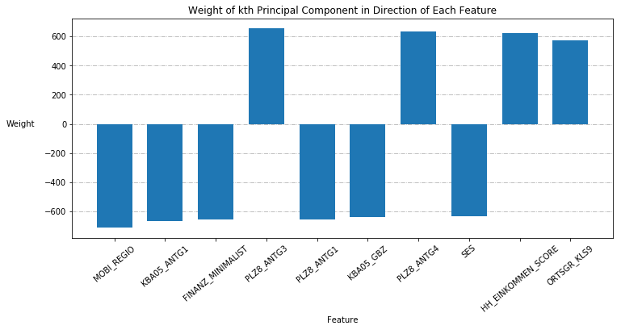

```python
# Map weights for the first principal component to corresponding feature names
# and then print the linked values, sorted by weight.

fw_pairs = map_pca_weights(data.columns, pca, 0)
plt.rcParams["figure.figsize"] = (12, 5)
plot_pca_weight_map(fw_pairs[0:10])
```

```python
'''
MOBI_REG -> movement patterns
KBA05_ANTG1 -> Number of 1-2 family houses in the microcell
FINANZ_MINIMALIST -> financial typology: low financial interest
PLZ8_ANTG3 -> Number of 6-10 family houses in the PLZ8 region
PLZ8_ANTG1 -> Number of 1-2 family houses in the PLZ8 region
KBA05_GBZ -> Number of buildings in the microcell
PLZ8_ANTG4 -> Number of 10+ family houses in the PLZ8 region
SES -> Socioeconomic Status
HH_EINKOMMEN_SCORE -> Estimated household net income
ORTSGR_KLS9 -> Size of community
'''
```

```
'\nMOBI_REG -> movement patterns\nKBA05_ANTG1 -> Number of 1-2 family houses in the microcell\nFINANZ_MINIMALIST -> financial typology: low financial interest\nPLZ8_ANTG3 -> Number of 6-10 family houses in the PLZ8 region\nPLZ8_ANTG1 -> Number of 1-2 family houses in the PLZ8 region\nKBA05_GBZ -> Nu…
```

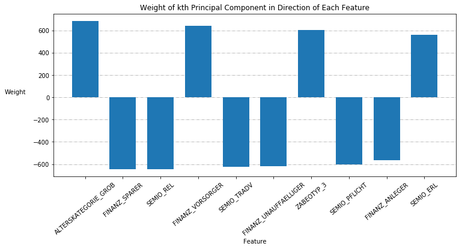

```python
# Map weights for the second principal component to corresponding feature names
# and then print the linked values, sorted by weight.

fw_pairs = map_pca_weights(data.columns, pca, 1)
plt.rcParams["figure.figsize"] = (12, 5)
plot_pca_weight_map(fw_pairs[0:10])
```

```python
'''
ALTERSKATEGORIE_GROB -> Estimated age based on given name analysis
FINANZ_SPARER -> financial typology: money-saver
SEMIO_REL -> Personality typology: religious
FINANZ_VORSORGER -> Financial typology: be prepared
SEMIO_TRADV -> Personality typology: tradional-minded
FINANZ_UNAUFFAELLIGER -> inconspicuous
ZABIOTYP_3 -> Energy consumption typology: fair supplied
SEMIO_PFLICHT -> Personality typology: dutiful
FINANZ_ANLEGER -> Financial typology: investor
SEMIO_ERL -> Personality typology: event-oriented
'''
```

```
'\nALTERSKATEGORIE_GROB -> Estimated age based on given name analysis\nFINANZ_SPARER -> financial typology: money-saver\nSEMIO_REL -> Personality typology: religious\nFINANZ_VORSORGER -> Financial typology: be prepared\nSEMIO_TRADV -> Personality typology: tradional-minded\nFINANZ_UNAUFFAELLIGER -> …
```

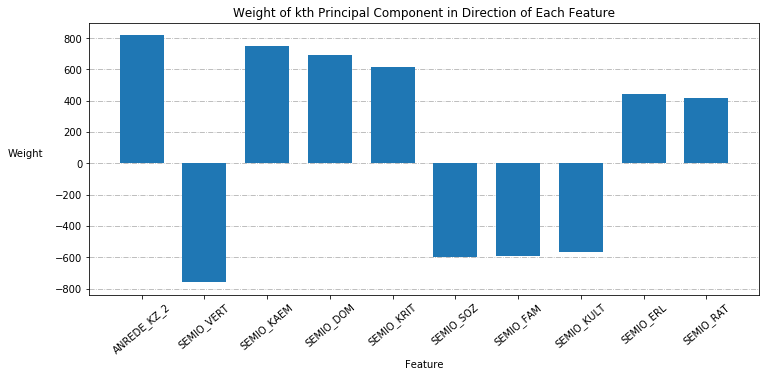

```python
# Map weights for the third principal component to corresponding feature names
# and then print the linked values, sorted by weight.

fw_pairs = map_pca_weights(data.columns, pca, 2)
plt.rcParams["figure.figsize"] = (12, 5)
plot_pca_weight_map(fw_pairs[0:10])
```

```python
'''
ANREDE_KZ_2 -> gender
SEMIO_VERT -> Personality typology: dreamful
SEMIO_KAEM -> Personality typology: combative attitude
SEMIO_DOM -> Personality typology: dominant-minded
SEMIO_KRIT -> Personality typology: critical-minded
SEMIO_SOZ -> Personality typology: socially-minded
SEMIO_FAM -> Personality typology: family-minded
SEMIO_KULT -> Personality typology: cultural-minded
SEMIO_ERL -> Personality typology: event-oriented
SEMIO_RAT -> Personality typology: rational
'''
```

```
'\nANREDE_KZ_2 -> gender\nSEMIO_VERT -> Personality typology: dreamful\nSEMIO_KAEM -> Personality typology: combative attitude\nSEMIO_DOM -> Personality typology: dominant-minded\nSEMIO_KRIT -> Personality typology: critical-minded\nSEMIO_SOZ -> Personality typology: socially-minded\nSEMIO_FAM -> Pe…
```

### Discussion 2.3: Interpret Principal Components

Principal components represent latent features underlying the observed features. The principal component vectors can be interpreted (somewhat subjectively).

The first three prinicpal components I identified each cluster together related attributes.

The first vector describes relationships between family size, community size, geographical mobility, and socioeconomic status. The associated latent variable may capture elements of rural vs. urban community, community cohesion, and community wealth.

The second vector describes relationships between financial reservedness, personal reservedness,conscientiousness, and age. The variable may capture elements of risk-aversion and conscientiousness, and possibly how those attributes change over a person's lifespan.

The third vector describes personality traits associated with extraversion, prosicial behavior, antisocial behavior, and gender.

In summary, the principal components have meaning as latent variables which connect underlying relationships between the original features to form new ways of describing observations. Such latent variables are sometimes thought to describe more fundamental qualities that observed features measure indirectly. In the present case, the transformed features have clear internal consistency. However, interpretations latent variables are subject to human biases.

## Step 3: Clustering

### Step 3.1: Apply Clustering to General Population

You've assessed and cleaned the demographics data, then scaled and transformed them. Now, it's time to see how the data clusters in the principal components space. In this substep, you will apply k-means clustering to the dataset and use the squared within-cluster distances from each point to their assigned cluster's centroid to decide on a number of clusters to keep.

```python
# Over a number of different cluster counts...
# run k-means clustering on the data and...
# compute the average within-cluster distances.

# Note that the objective function minimizes the sum of squared distances, not the average distance
# I am plotting the mean squared within-cluster distances (I'm taking the mean so the resulting numbers are smaller)
# Note that KMeans().inertia_ == -KMeans().score()
objective = []
silhouette = []
calinski_harabaz = []
num_means = 20
for k in range(2, num_means+1):

    kmeans = KMeans(n_clusters=k, random_state=23953)
    predictions = kmeans.fit_predict(data_pca)

    o = kmeans.inertia_ / data_pca.shape[0]
    objective.append(o)

    s = silhouette_score(data_pca, predictions, sample_size=int(0.025*data_pca.shape[0]))
    silhouette.append(s)

    ch = calinski_harabaz_score(data_pca, predictions)
    calinski_harabaz.append(ch)

    print(f'Completed iteration with {k} means')
```

```
Completed iteration with 2 means
Completed iteration with 3 means
Completed iteration with 4 means
Completed iteration with 5 means
Completed iteration with 6 means
Completed iteration with 7 means
Completed iteration with 8 means
Completed iteration with 9 means
Completed iteration with 10 means
Completed iteration with 11 means
Completed iteration with 12 means
Completed iteration with 13 means
Completed iteration with 14 means
Completed iteration with 15 means
Completed iteration with 16 means
Completed iteration with 17 means
Completed iteration with 18 means
Completed iteration with 19 means
Completed iteration with 20 means
```

```python
for k in range(0, num_means-1):
    print(f'Means: {k+2}\tMSD: {objective[k]:.2f}\tSilhouette: {silhouette[k]:.3f}\tCalinski-Harabaz: {calinski_harabaz[k]:.2f}')
```

```
Means: 2	MSD: 27.11	Silhouette: 0.246	Calinski-Harabaz: 289460.75
Means: 3	MSD: 22.06	Silhouette: 0.239	Calinski-Harabaz: 269259.99
Means: 4	MSD: 19.05	Silhouette: 0.221	Calinski-Harabaz: 249790.10
Means: 5	MSD: 17.05	Silhouette: 0.225	Calinski-Harabaz: 232649.57
Means: 6	MSD: 15.40	Silhouette: 0.232	Calinski-Harabaz: 223268.21
Means: 7	MSD: 13.99	Silhouette: 0.242	Calinski-Harabaz: 218107.70
Means: 8	MSD: 12.77	Silhouette: 0.250	Calinski-Harabaz: 215884.11
Means: 9	MSD: 11.92	Silhouette: 0.249	Calinski-Harabaz: 209371.58
Means: 10	MSD: 11.15	Silhouette: 0.256	Calinski-Harabaz: 204955.51
Means: 11	MSD: 10.62	Silhouette: 0.257	Calinski-Harabaz: 197827.96
Means: 12	MSD: 10.25	Silhouette: 0.244	Calinski-Harabaz: 188986.95
Means: 13	MSD: 9.82	Silhouette: 0.245	Calinski-Harabaz: 183690.31
Means: 14	MSD: 9.47	Silhouette: 0.241	Calinski-Harabaz: 177979.18
Means: 15	MSD: 9.13	Silhouette: 0.237	Calinski-Harabaz: 173611.02
Means: 16	MSD: 8.82	Silhouette: 0.227	Calinski-Harabaz: 169508.58
Means: 17	MSD: 8.60	Silhouette: 0.219	Calinski-Harabaz: 164318.08
Means: 18	MSD: 8.30	Silhouette: 0.229	Calinski-Harabaz: 161901.43
Means: 19	MSD: 8.12	Silhouette: 0.221	Calinski-Harabaz: 157451.20
Means: 20	MSD: 7.90	Silhouette: 0.221	Calinski-Harabaz: 154411.78
```

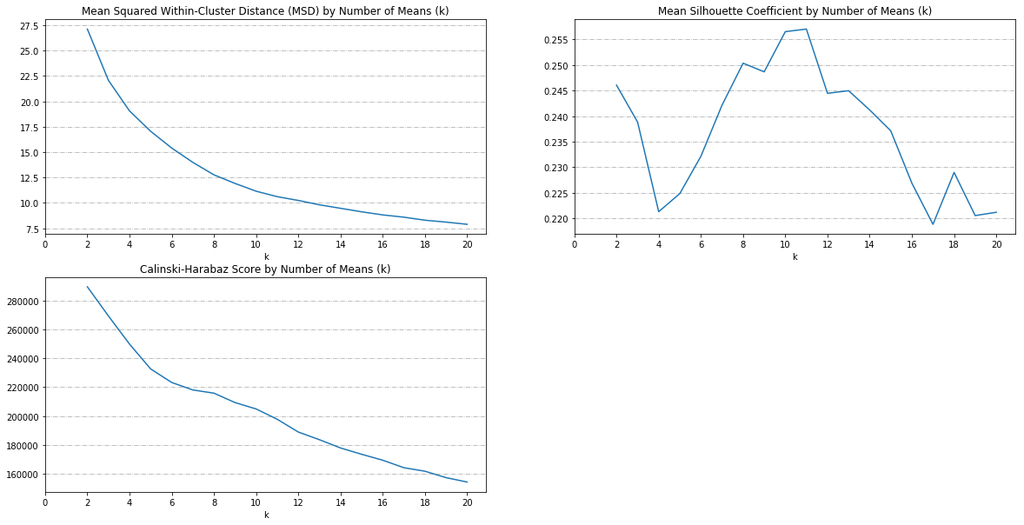

```python
# Investigate the change in within-cluster distance across number of clusters.

plt.rcParams["figure.figsize"] = (20, 10)
fig = plt.Figure()

# MSE
plt.subplot(2, 2, 1)
plt.plot(range(2, num_means+1, 1), objective, zorder=2)
plt.title('Mean Squared Within-Cluster Distance (MSD) by Number of Means (k)')
plt.xlabel('k')
plt.xticks(range(0, num_means+1, 2))
plt.grid(axis='y', linestyle='-.', zorder=1)

# Silhouette coefficient
plt.subplot(2, 2, 2)
plt.plot(range(2, num_means+1, 1), silhouette, zorder=2)
plt.title('Mean Silhouette Coefficient by Number of Means (k)')
plt.xlabel('k')
plt.xticks(range(0, num_means+1, 2))
plt.grid(axis='y', linestyle='-.', zorder=1)

# Calinski-Harabaz Score
plt.subplot(2, 2, 3)
plt.plot(range(2, num_means+1, 1), calinski_harabaz, zorder=2)
plt.title('Calinski-Harabaz Score by Number of Means (k)')
plt.xlabel('k')
plt.xticks(range(0, num_means+1, 2))
plt.grid(axis='y', linestyle='-.', zorder=1)

plt.show()
```

```python
# Re-fit the k-means model with the selected number of clusters and obtain
# cluster predictions for the general population demographics data.
num_clusters = 11
kmeans = KMeans(n_clusters=num_clusters, verbose=0, random_state=573478)
kmeans.fit(data_pca)
demo_preds = kmeans.predict(data_pca)
demo_preds = pd.Series(demo_preds)
```

### Discussion 3.1: Apply Clustering to General Population

I clustered the population into eleven segments. I made this decision based on the marginal improvement in within-cluster variance, the Silhouette Coefficient, and the Calinski-Harabaz Score.

The Silhouette Coefficient is a scaled difference of the distance between clusters and the distance of points to their cluster means. It performs well with convex clusters, and is higher when clusters are dense and well-separated. The coefficient range is between -1 and 1, with higher scores representing "better" clustering.

The Calinski-Harabaz Score is the ratio of mean between-cluster variance and mean within-cluster variance. A well-defined cluster model has high variance (i.e. dispersion) between clusters and low within-cluster variance, so a higher Calinski-Harabaz Score suggests a better solution.

I chose to implement elven clusters because this value produces a maximum for the Silhouette Coefficient and is intuitively appropriate given the mean square error "elbow chart". I have tried several adjustments to my preprocessing pipeline, large and small, and have been unable to produce substantively better results.

### Step 3.2: Apply All Steps to the Customer Data

Now that you have clusters and cluster centers for the general population, it's time to see how the customer data maps on to those clusters. Take care to not confuse this for re-fitting all of the models to the customer data. Instead, you're going to use the fits from the general population to clean, transform, and cluster the customer data. In the last step of the project, you will interpret how the general population fits apply to the customer data.

```python
# Load in the customer demographics data.
customers = pd.read_csv('Udacity_CUSTOMERS_Subset.csv', delimiter=';')
customers = pd.DataFrame(customers)
```

```python
# Apply preprocessing, feature transformation, and clustering from the general
# demographics onto the customer data, obtaining cluster predictions for the
# customer demographics data.
customer_data = Utils.clean_data(customers, feat_info)
for label in data.columns:
    if label not in customer_data.columns:
        customer_data[label] = 0

customer_data = imputer.transform(customer_data)
customer_scaled = scaler.transform(customer_data)
customer_pca = pca.transform(customer_scaled)
customer_pca = pd.DataFrame(customer_pca)
customer_preds = kmeans.predict(customer_pca)
customer_preds = pd.Series(customer_preds)
```

### Step 3.3: Compare Customer Data to Demographics Data

At this point, you have clustered data based on demographics of the general population of Germany, and seen how the customer data for a mail-order sales company maps onto those demographic clusters. In this final substep, you will compare the two cluster distributions to see where the strongest customer base for the company is.

Consider the proportion of persons in each cluster for the general population, and the proportions for the customers. If we think the company's customer base to be universal, then the cluster assignment proportions should be fairly similar between the two. If there are only particular segments of the population that are interested in the company's products, then we should see a mismatch from one to the other. If there is a higher proportion of persons in a cluster for the customer data compared to the general population (e.g. 5% of persons are assigned to a cluster for the general population, but 15% of the customer data is closest to that cluster's centroid) then that suggests the people in that cluster to be a target audience for the company. On the other hand, the proportion of the data in a cluster being larger in the general population than the customer data (e.g. only 2% of customers closest to a population centroid that captures 6% of the data) suggests that group of persons to be outside of the target demographics.

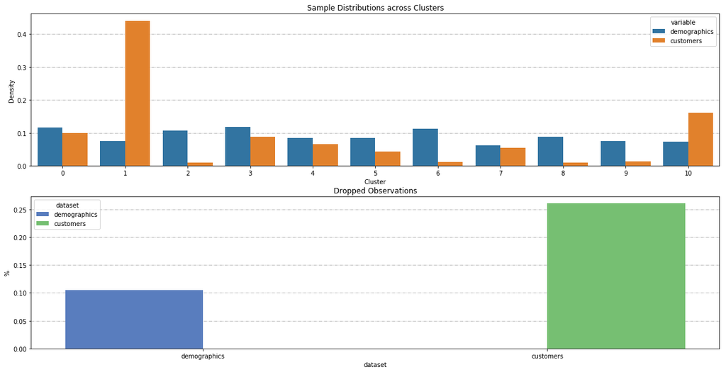

```python
# Compare the proportion of data in each cluster for the customer data to the
# proportion of data in each cluster for the general population.
yvar_demo = demo_preds.value_counts(normalize=True, sort=False)
yvar_customer = customer_preds.value_counts(normalize=True, sort=False)
df = pd.DataFrame.from_dict({'demographics': yvar_demo, 'customers': yvar_customer, 'cluster': list(range(0,num_clusters))})
df = pd.melt(df, id_vars='cluster', value_vars=['demographics', 'customers'])

miss_demo = (len(azdias)-len(data))/len(azdias)
miss_cust = (len(customers)-len(customer_data))/len(customers)
miss_df = pd.DataFrame.from_dict({'dataset': ['demographics', 'customers'], 'pmiss': [miss_demo, miss_cust]})

plt.rcParams["figure.figsize"] = (20, 10)
fig = plt.Figure()

plt.subplot(2, 1, 1)
sns.barplot(x=df.cluster, y=df.value, hue=df.variable, palette=sns.color_palette(), zorder=2)
plt.grid(axis='y', linestyle='-.', zorder=1)
plt.title('Sample Distributions across Clusters')
plt.xlabel('Cluster')
plt.ylabel('Density')

plt.subplot(2, 1, 2)
sns.barplot(x=miss_df.dataset, y=miss_df.pmiss, hue=miss_df.dataset,
            palette=sns.color_palette('muted'), zorder=2)
plt.grid(axis='y', linestyle='-.', zorder=1)
plt.title('Dropped Observations')
plt.ylabel('%')

plt.show()
```

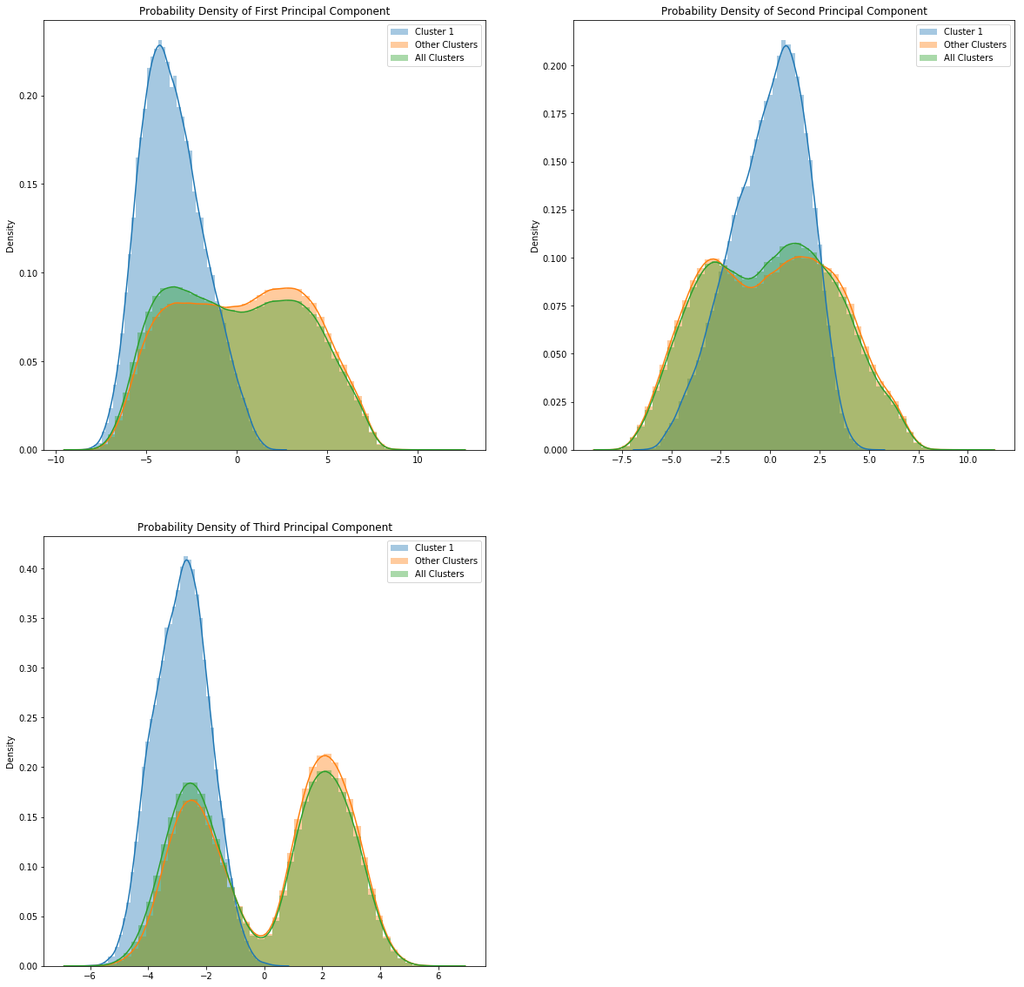

```python
# What kinds of people are part of a cluster that is overrepresented in the
# customer data compared to the general population?
data_pca['cluster'] = demo_preds
data_pca_cluster1 = data_pca[data_pca['cluster']==1]
data_pca_other = data_pca[data_pca['cluster']!=1]

plt.rcParams["figure.figsize"] = (20, 20)
fig = plt.Figure()

ax = plt.subplot(2, 2, 1)
sns.distplot(data_pca_cluster1[[0]], ax=ax, label='Cluster 1')
sns.distplot(data_pca_other[[0]], ax=ax, label='Other Clusters')
sns.distplot(data_pca[[0]], ax=ax, label='All Clusters')
plt.title('Probability Density of First Principal Component')
plt.ylabel('Density')
plt.legend()

ax = plt.subplot(2, 2, 2)
sns.distplot(data_pca_cluster1[[1]], ax=ax, label='Cluster 1')
sns.distplot(data_pca_other[[1]], ax=ax, label='Other Clusters')
sns.distplot(data_pca[[1]], ax=ax, label='All Clusters')
plt.title('Probability Density of Second Principal Component')
plt.ylabel('Density')
plt.legend()

ax = plt.subplot(2, 2, 3)
sns.distplot(data_pca_cluster1[[2]], ax=ax, label='Cluster 1')
sns.distplot(data_pca_other[[2]], ax=ax, label='Other Clusters')
sns.distplot(data_pca[[2]], ax=ax, label='All Clusters')
plt.title('Probability Density of Third Principal Component')
plt.ylabel('Density')
plt.legend()

plt.show()
```

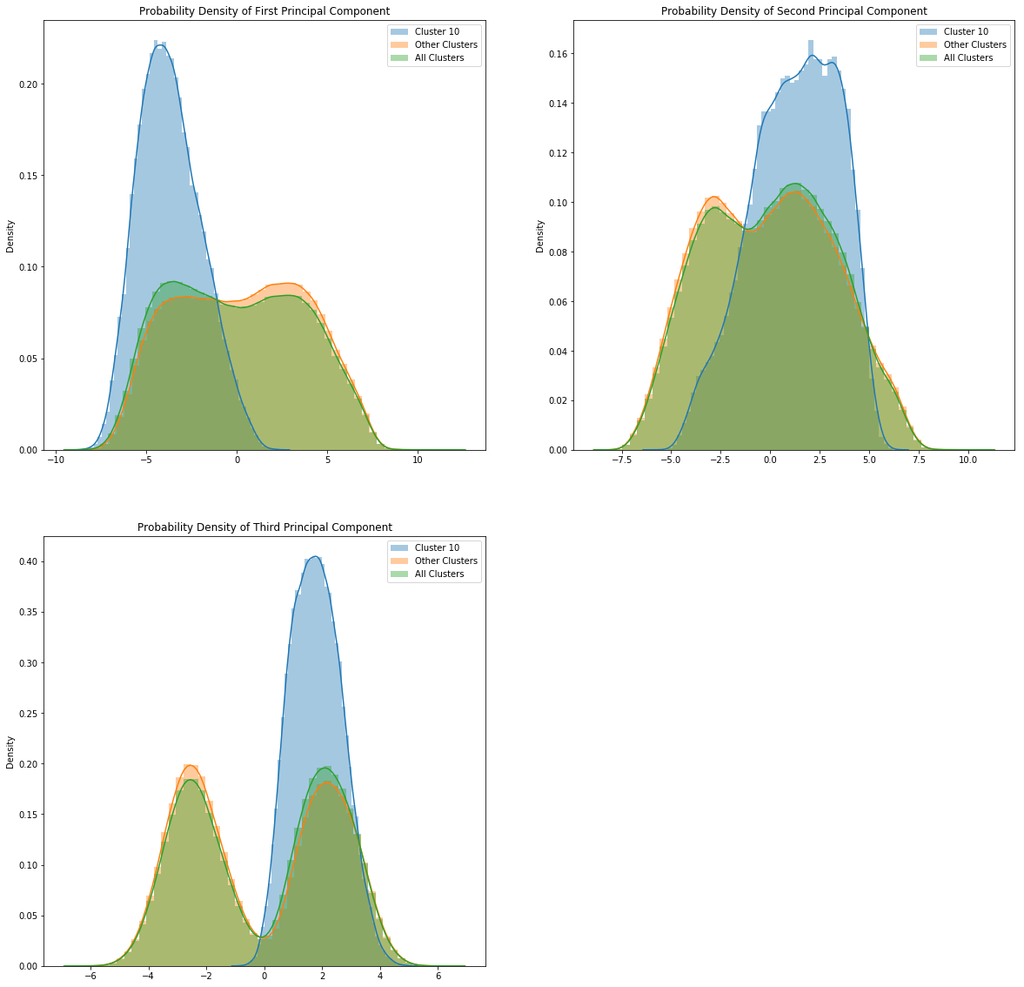

```python
# What kinds of people are part of a cluster that is underrepresented in the
# customer data compared to the general population?
data_pca['cluster'] = demo_preds
data_pca_cluster10 = data_pca[data_pca['cluster']==10]
data_pca_other = data_pca[data_pca['cluster']!=10]

plt.rcParams["figure.figsize"] = (20, 20)
fig = plt.Figure()

ax = plt.subplot(2, 2, 1)
sns.distplot(data_pca_cluster10[[0]], ax=ax, label='Cluster 10')
sns.distplot(data_pca_other[[0]], ax=ax, label='Other Clusters')
sns.distplot(data_pca[[0]], ax=ax, label='All Clusters')
plt.title('Probability Density of First Principal Component')
plt.ylabel('Density')
plt.legend()

ax = plt.subplot(2, 2, 2)
sns.distplot(data_pca_cluster10[[1]], ax=ax, label='Cluster 10')
sns.distplot(data_pca_other[[1]], ax=ax, label='Other Clusters')
sns.distplot(data_pca[[1]], ax=ax, label='All Clusters')
plt.title('Probability Density of Second Principal Component')
plt.ylabel('Density')
plt.legend()

ax = plt.subplot(2, 2, 3)
sns.distplot(data_pca_cluster10[[2]], ax=ax, label='Cluster 10')
sns.distplot(data_pca_other[[2]], ax=ax, label='Other Clusters')
sns.distplot(data_pca[[2]], ax=ax, label='All Clusters')
plt.title('Probability Density of Third Principal Component')
plt.ylabel('Density')
plt.legend()

plt.show()
```

### Discussion 3.3: Compare Customer Data to Demographics Data

The company's customer base is highly overrepresented in the second and 11th clusters, and underrepresented in the remaining clusters. I compared the first three principal component distributions for clusters two and 11.

The first principal component describes relationships between family size, community size, geographical mobility, and socioeconomic status. The associated latent variable may capture elements of rural vs. urban community, community cohesion, and community wealth. Higher values are related to larger families in larger communities, with lower socioeconomic status but higher overall net income.

The second principal component describes relationships between financial reservedness, personal reservedness,conscientiousness, and age. The variable may capture elements of risk-aversion and conscientiousness, and possibly how those attributes change over a person's lifespan. Higher values are related to older people who are less risk-averse and traditional and more financially responsible.

The third principal component describes personality traits associated with extraversion, prosicial behavior, antisocial behavior, and gender. Higher values are related to lower extraversion and social behavior, and higher disagreeability.

Compared to other clusters, the second cluster has much lower and more concentrated values in the first principal and third components. Cluster two has a narrower second component distribution than the combined other clusters, but the distribution has a similar median.

Compared to other clusters, the 11th cluster has much lower values for the first principal component, slightly higher values for the second principal component, and much higher values for the third component. These three distributions are narrow (i.e. have low variance).

Interestingly, each of the three prinicipal components I examined have bimodal distributions. This suggests they may be better represented by two distinct variables. We may be able to improve our model by collecting more data. By increasing our sample size, we can create coherent clusters in a higher dimensional feature space.

About 60% of the company's customer base are concentrated in the second and 11th clusters, while only 15% of the broader German demography are assigned to those clusters.